<sub>This work follows along with the [lab content](https://github.com/fchollet/deep-learning-with-python-notebooks) provided from [Deep Learning with Python (Manning Publications)](https://www.manning.com/books/deep-learning-with-python?a_aid=keras&a_bid=76564dff).</sub>

This notebook is available here: https://github.com/bgodd/deep_learning

# Predicting Home Sale Prices

## AMES Data

Data set available here: https://www.kaggle.com/c/house-prices-advanced-regression-techniques/data

This data set is an alternative to the popular Boston Data Set for learning data science principles.

### Initial library loading

```python
%matplotlib inline
```

```python
import pandas as pd
import numpy as np
```

```python
import keras
keras.__version__
```

### Loading and Cleaning Data

```python
ames_df = pd.read_csv('data/train.csv')
```

Here we will prep a list of columns that we plan on dropping later and combining a few different columns into one to simplify the model but still capture data.

```python
to_drop = ['MiscFeature', 'MiscVal', 'GarageArea', 'GarageYrBlt', 'Street', 'Alley',
          'LotShape', 'LandContour', 'LandSlope', 'RoofMatl', 'Exterior2nd', 'MasVnrType',
          'MasVnrArea', 'BsmtCond', 'BsmtExposure', 'BsmtFinType1', 'BsmtFinType2',
          'BsmtFinSF1', 'BsmtFinSF1', 'BsmtUnfSF', 'TotalBsmtSF', 'Heating', 'Electrical',
          'LowQualFinSF', 'GrLivArea', 'BsmtFullBath', 'BsmtHalfBath', 'FullBath',
          'HalfBath', 'KitchenQual', 'TotRmsAbvGrd', 'Functional', 'FireplaceQu',
          'GarageType', 'GarageFinish', 'GarageQual', 'PavedDrive', 'WoodDeckSF', 'OpenPorchSF',
          'EnclosedPorch', '3SsnPorch', 'ScreenPorch', 'PoolQC', 'MoSold']

ames_df['Bathrooms'] = ames_df['FullBath'] + ames_df['HalfBath'] + ames_df['BsmtFullBath'] + ames_df['BsmtHalfBath']
ames_df['PorchSF'] = ames_df['EnclosedPorch'] + ames_df['OpenPorchSF']
ames_df = ames_df.drop(to_drop, axis=1)
```

We will address Null data by filling in those elements with the mode of each column. We will also normalize each column's values (except the SalePrice and Id columns and columns that are made up of categorical data).

```python
to_ignore = ['SalePrice', 'Id']
for column in ames_df.columns:
    x = ames_df[column].dropna().value_counts().index[0]
    ames_df = ames_df.fillna(x)
    if ames_df[column].dtype != 'object' and column not in to_ignore:
        m = ames_df[column].min()
        M = ames_df[column].max()
        Range = M - m
        ames_df[column] = (ames_df[column] - m) / Range
```

To address columns with categorical data, we will use pandas's inbuilt systems for converting these values to int values.

```python
num_cols = ames_df._get_numeric_data().columns
for col in ames_df[ames_df.columns.difference(num_cols)].columns:
    ames_df[col] = ames_df[col].astype("category").cat.codes
```

## Create Test and Training Splits

For this data, we do not have a pre-split training and test data, so we will make that ourselves by establishing a hold out set for testing later after model creation.

```python
print('Original Data Shape')
print(ames_df.shape)
msk = np.random.rand(len(ames_df)) < 0.8

# Create Training Data:
train_data = ames_df[msk]
# Create Test Data:
test_data = ames_df[~msk]

print('Split Data Shapes')
print(train_data.shape)
print(test_data.shape)
```

```
Original Data Shape
(1460, 40)
Split Data Shapes
(1172, 40)
(288, 40)
```

Finally, we will convert the data in data and target values and then into NumPy format.

```python
# Convert into numpy arrays
train_data = train_data_pre.drop(['SalePrice', 'Id'], axis=1).as_matrix().astype(np.float32)
train_targets = train_data_pre['SalePrice'].as_matrix().astype(np.float32).reshape((np.shape(train_data)[0], 1))
test_data = test_data_pre.drop(['SalePrice', 'Id'], axis=1).as_matrix().astype(np.float32)
test_targets = test_data_pre['SalePrice'].as_matrix().astype(np.float32).reshape((np.shape(test_data)[0], 1))
```

## Setting up a network

```python
from keras import models
from keras import layers

def build_model():
    # Because we will need to instantiate
    # the same model multiple times,
    # we use a function to construct it.
    model = models.Sequential()
    model.add(layers.Dense(64, activation='relu',
                           input_shape=(train_data.shape[1],)))
    model.add(layers.Dense(96, activation='relu'))
    model.add(layers.Dense(128, activation='relu'))
    model.add(layers.Dense(96, activation='relu'))
    model.add(layers.Dense(64, activation='relu'))
    model.add(layers.Dense(1))
    model.compile(optimizer='rmsprop', loss='mse', metrics=['mae'])
    return model
```

## K-fold validation

```python
# # Some memory clean-up
# from keras import backend as K
# K.clear_session()
```

```python
k=4
num_epochs = 500
all_mae_histories = []

for i in range(k):
    print('processing fold #', i)
    # Prepare the validation data: data from partition # k
    val_data = train_data[i * num_val_samples: (i + 1) * num_val_samples]
    val_targets = train_targets[i * num_val_samples: (i + 1) * num_val_samples]

    # Prepare the training data: data from all other partitions
    partial_train_data = np.concatenate(
        [train_data[:i * num_val_samples],
         train_data[(i + 1) * num_val_samples:]],
        axis=0)
    partial_train_targets = np.concatenate(
        [train_targets[:i * num_val_samples],
         train_targets[(i + 1) * num_val_samples:]],
        axis=0)

    # Build the Keras model (already compiled)
    model = build_model()
    # Train the model (in silent mode, verbose=0)
    history = model.fit(partial_train_data, partial_train_targets,
                        validation_data=(val_data, val_targets),
                        epochs=num_epochs, batch_size=1, verbose=0)
    mae_history = history.history['mean_absolute_error']
    all_mae_histories.append(mae_history)
```

```
processing fold # 0
processing fold # 1
processing fold # 2
processing fold # 3
```

```python
average_mae_history = [
    np.mean([x[i] for x in all_mae_histories]) for i in range(num_epochs)]
```

### Plotting the average of the per-epoch MAE scores

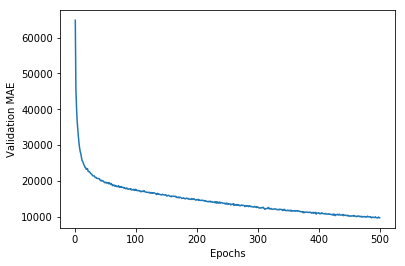

```python
import matplotlib.pyplot as plt

plt.plot(range(1, len(average_mae_history) + 1), average_mae_history)
plt.xlabel('Epochs')
plt.ylabel('Validation MAE')
plt.show()
```

```python
# Get a fresh, compiled model.
model = build_model()
# Train it on the entirety of the data.
model.fit(train_data, train_targets, epochs=200, batch_size=16, verbose=0)
```

```
<keras.callbacks.History at 0x1a28c37940>
```

```python
test_mse_score, test_mae_score = model.evaluate(test_data, test_targets)
```

```python
test_mae_score
```

```
18336.395975144391
```

```python
ames_df['SalePrice'].describe()
```

```
count      1460.000000
mean     180921.195890
std       79442.502883
min       34900.000000
25%      129975.000000
50%      163000.000000
75%      214000.000000
max      755000.000000
Name: SalePrice, dtype: float64
```

## Wrapping up

Given this set of data we were able to create a model that could predict the sale price of a home with a MAE of \$18,336. The mean value of homes in this data set is \$180,921 with a min and max of \$34,900 and \$755,000 respectively. Certainly, improvements could be made, but working off this data alone it's impressive how well this model is able to predict home values.